# Self-Driving Car Engineer Nanodegree

## Project: Build a Traffic Sign Recognition Classifier

In this notebook, a template is provided for you to implement your functionality in stages, which is required to successfully complete this project. If additional code is required that cannot be included in the notebook, be sure that the Python code is successfully imported and included in your submission if necessary.

In addition to implementing code, there is a writeup to complete. The writeup should be completed in a separate file, which can be either a markdown file or a pdf document. There is a [write up template](https://github.com/udacity/CarND-Traffic-Sign-Classifier-Project/blob/master/writeup_template.md) that can be used to guide the writing process. Completing the code template and writeup template will cover all of the [rubric points](https://review.udacity.com/#!/rubrics/481/view) for this project.

The [rubric](https://review.udacity.com/#!/rubrics/481/view) contains "Stand Out Suggestions" for enhancing the project beyond the minimum requirements. The stand out suggestions are optional. If you decide to pursue the "stand out suggestions", you can include the code in this Ipython notebook and also discuss the results in the writeup file.

> **Note:** Code and Markdown cells can be executed using the **Shift + Enter** keyboard shortcut. In addition, Markdown cells can be edited by typically double-clicking the cell to enter edit mode.

## Step 0: Load The Data

## Step 1: Dataset Summary & Exploration

The pickled data is a dictionary with 4 key/value pairs:

- `'features'` is a 4D array containing raw pixel data of the traffic sign images, (num examples, width, height, channels).
- `'labels'` is a 1D array containing the label/class id of the traffic sign. The file `signnames.csv` contains id -> name mappings for each id.
- `'sizes'` is a list containing tuples, (width, height) representing the original width and height the image.
- `'coords'` is a list containing tuples, (x1, y1, x2, y2) representing coordinates of a bounding box around the sign in the image. **THESE COORDINATES ASSUME THE ORIGINAL IMAGE. THE PICKLED DATA CONTAINS RESIZED VERSIONS (32 by 32) OF THESE IMAGES**

Complete the basic data summary below. Use python, numpy and/or pandas methods to calculate the data summary rather than hard coding the results. For example, the [pandas shape method](http://pandas.pydata.org/pandas-docs/stable/generated/pandas.DataFrame.shape.html) might be useful for calculating some of the summary results.

```python
# Load pickled data
import pickle
import random
import numpy as np
import tensorflow as tf
from sklearn.utils import shuffle



# TODO: Fill this in based on where you saved the training and testing data

training_file = '/home/workspace/data/train.p'
training_g_file = '/home/workspace/data/train_gray.p'
training_n_file = '/home/workspace/data/train_normalized.p'

validation_file= '/home/workspace/data/valid.p'
testing_file = '/home/workspace/data/test.p'

with open(training_file, mode='rb') as f:
    train = pickle.load(f)
with open(training_g_file, mode='rb') as f:
    train_g = pickle.load(f)
with open(training_n_file, mode='rb') as f:
    train_n = pickle.load(f)
with open(validation_file, mode='rb') as f:
    valid = pickle.load(f)
with open(testing_file, mode='rb') as f:
    test = pickle.load(f)

X_train, y_train = train['features'], train['labels']
X_train_g, y_train_g = train_g['features'], train_g['labels']
X_train_n, y_train_n = train_n['features'], train_n['labels']

XX_train = np.concatenate((X_train, X_train_g))
XX_train = np.concatenate((XX_train, X_train_n))
yy_train = np.concatenate((y_train, y_train_g))
yy_train = np.concatenate((yy_train, y_train_n))

X_valid, y_valid = valid['features'], valid['labels']
X_test, y_test = test['features'], test['labels']

print(f'Training: Input {len(X_train)}, Labels: {len(y_train)}')
print(f'Training: Input {len(XX_train)}, Labels: {len(yy_train)}')
print(f'Test: Input {len(X_test)}, Labels: {len(y_test)}')
print(f'Validation: Input {len(X_valid)}, Labels: {len(y_valid)}')

#print(f'Image Type: {type(X_valid[0])}: Value: {len(X_valid[0])}')
```

```
Training: Input 34799, Labels: 34799
Training: Input 104397, Labels: 104397
Test: Input 12630, Labels: 12630
Validation: Input 4410, Labels: 4410
```

### Provide a Basic Summary of the Data Set Using Python, Numpy and/or Pandas

```python
### Replace each question mark with the appropriate value.
### Use python, pandas or numpy methods rather than hard coding the results

# TODO: Number of training examples
n_train = len(XX_train)

# TODO: Number of validation examples
n_validation = len(X_valid)

# TODO: Number of testing examples.
n_test = len(X_test)

# TODO: What's the shape of an traffic sign image?
image_shape = XX_train[0].shape

# TODO: How many unique classes/labels there are in the dataset.
n_classes = 43

print("Number of training examples =", n_train)
print("Number of testing examples =", n_test)
print("Image data shape =", image_shape)
print("Number of classes =", n_classes)
```

```
Number of training examples = 104397
Number of testing examples = 12630
Image data shape = (32, 32, 3)
Number of classes = 43
```

```
7
(32, 32, 3)
```

[figure not shown]

```python
### Data exploration visualization code goes here.
### Feel free to use as many code cells as needed.
#import matplotlib.pyplot as plt
#import random
# Visualizations will be shown in the notebook.
#%matplotlib inline

import random
import matplotlib.pyplot as plt

get_ipython().run_line_magic('matplotlib', 'inline')

index = random.randint(0, len(XX_train))
image = XX_train[index].squeeze()
plt.figure(figsize=(6,6))
plt.imshow(image)
print(yy_train[index])
print(image.shape)

#TODO:

# Create a distribution of classes.
```

### Include an exploratory visualization of the dataset

Visualize the German Traffic Signs Dataset using the pickled file(s). This is open ended, suggestions include: plotting traffic sign images, plotting the count of each sign, etc.

The [Matplotlib](http://matplotlib.org/) [examples](http://matplotlib.org/examples/index.html) and [gallery](http://matplotlib.org/gallery.html) pages are a great resource for doing visualizations in Python.

**NOTE:** It's recommended you start with something simple first. If you wish to do more, come back to it after you've completed the rest of the sections. It can be interesting to look at the distribution of classes in the training, validation and test set. Is the distribution the same? Are there more examples of some classes than others?

### Breakdown of data included in the project

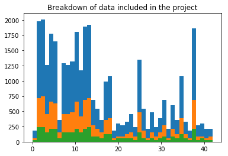

```python
plt.hist(y_train, bins=n_classes);

plt.hist(y_test, bins=n_classes);

plt.hist(y_valid, bins=n_classes);

plt.title('Breakdown of data included in the project');
```

### Breakdown of data after adding pre-processed images

- I went through the training data set images and created a normalized version and greyscale version.
- I also created new pickle files that contains the new images. Pickle files allow me to quickly load additional images for training.
- Pickle files can be found at '/home/workspace/data/train_gray.p' and '/home/workspace/data/train_normalized.p'

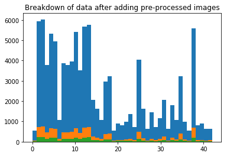

```python
plt.hist(yy_train, bins=n_classes);

plt.hist(y_test, bins=n_classes);

plt.hist(y_valid, bins=n_classes);

plt.title('Breakdown of data after adding pre-processed images');
```

## Step 2: Design and Test a Model Architecture

Design and implement a deep learning model that learns to recognize traffic signs. Train and test your model on the [German Traffic Sign Dataset](http://benchmark.ini.rub.de/?section=gtsrb&subsection=dataset).

The LeNet-5 implementation shown in the classroom at the end of the CNN lesson is a solid starting point. You'll have to change the number of classes and possibly the preprocessing, but aside from that it's plug and play!

With the LeNet-5 solution from the lecture, you should expect a validation set accuracy of about 0.89. To meet specifications, the validation set accuracy will need to be at least 0.93. It is possible to get an even higher accuracy, but 0.93 is the minimum for a successful project submission.

There are various aspects to consider when thinking about this problem:

- Neural network architecture (is the network over or underfitting?)
- Play around preprocessing techniques (normalization, rgb to grayscale, etc)
- Number of examples per label (some have more than others).
- Generate fake data.

Here is an example of a [published baseline model on this problem](http://yann.lecun.com/exdb/publis/pdf/sermanet-ijcnn-11.pdf). It's not required to be familiar with the approach used in the paper but, it's good practice to try to read papers like these.

### Pre-process the Data Set (normalization, grayscale, etc.)

Minimally, the image data should be normalized so that the data has mean zero and equal variance. For image data, `(pixel - 128)/ 128` is a quick way to approximately normalize the data and can be used in this project.

Other pre-processing steps are optional. You can try different techniques to see if it improves performance.

Use the code cell (or multiple code cells, if necessary) to implement the first step of your project.

```python
a = np.zeros((32, 32, 3))

image = X_train[0]
image_shape = image.shape

print(f'{a.shape} - Length - {len(a)}')
print(f'{image.shape} - Length - {len(image)}')

c = np.concatenate([a, image])
print(f'{c.shape} - Length - {len(c)}')
print(f'{X_train.shape} - Length - {len(X_train)}')

n_images, b_images, g_images = np.empty_like(X_train), np.empty_like(X_train), np.empty_like(X_train)
print(f'{n_images.shape} - Length - {len(n_images)}')

d = np.array(X_train.shape)
print(f'{d.shape} - Length - {len(d)}')


#X_arr = np.array(X_arr,dtype = np.float32())
#   Y_arr = np.array(Y_arr,dtype = np.float32())
```

```
(32, 32, 3) - Length - 32
(32, 32, 3) - Length - 32
(64, 32, 3) - Length - 64
(34799, 32, 32, 3) - Length - 34799
(34799, 32, 32, 3) - Length - 34799
(4,) - Length - 4
```

### Model Architecture

```python
from tensorflow.contrib.layers import flatten

SHOW_DEBUG = True

output = []
def debug(x, comment=None):
    if SHOW_DEBUG:
        if comment:
            print(f'{comment} - {x}')
        else:
            print(x.shape)


def LeNet(x, keep_prob, channels):
    # Arguments used for tf.truncated_normal, randomly defines variables for the weights and biases for each layer
    sess = tf.get_default_session()
    mu = 0
    sigma = 0.1

    # SOLUTION: Layer 1: Convolutional. Input = 32x32x3. Output = 28x28x6.
    conv1_W = tf.Variable(tf.truncated_normal(shape=(5, 5, 3, 6), mean = mu, stddev = sigma))
    conv1_b = tf.Variable(tf.zeros(6))
    conv1   = tf.nn.conv2d(x, conv1_W, strides=[1, 1, 1, 1], padding='VALID') + conv1_b

    # SOLUTION: Activation.
    conv1 = tf.nn.relu(conv1)
    conv1 = tf.nn.dropout(conv1, keep_prob)


    # SOLUTION: Pooling. Input = 28x28x6. Output = 14x14x6.
    conv1 = tf.nn.max_pool(conv1, ksize=[1, 2, 2, 1], strides=[1, 2, 2, 1], padding='VALID')
    conv1 = tf.nn.dropout(conv1, keep_prob)


    # SOLUTION: Layer 2: Convolutional. Input = 14x14x6. Output = 10x10x16.
    conv2_W = tf.Variable(tf.truncated_normal(shape=(5, 5, 6, 16), mean = mu, stddev = sigma))
    conv2_b = tf.Variable(tf.zeros(16))
    conv2   = tf.nn.conv2d(conv1, conv2_W, strides=[1, 1, 1, 1], padding='VALID') + conv2_b

    # SOLUTION: Activation.
    conv2 = tf.nn.relu(conv2)
    conv2 = tf.nn.dropout(conv2, keep_prob)

    # SOLUTION: Pooling. Input = 10x10x16. Output = 5x5x16.
    conv2 = tf.nn.max_pool(conv2, ksize=[1, 2, 2, 1], strides=[1, 2, 2, 1], padding='VALID')
    conv2 = tf.nn.dropout(conv2, keep_prob)


    # SOLUTION: Flatten. Input = 5x5x16. Output = 400.
    fc0   = flatten(conv2)

    # SOLUTION: Layer 3: Fully Connected. Input = 400. Output = 120.
    fc1_W = tf.Variable(tf.truncated_normal(shape=(400, 120), mean = mu, stddev = sigma))
    fc1_b = tf.Variable(tf.zeros(120))
    fc1   = tf.matmul(fc0, fc1_W) + fc1_b

    # SOLUTION: Activation.
    fc1    = tf.nn.relu(fc1)
    # NEW
    fc1    = tf.nn.dropout(fc1, keep_prob)

    # SOLUTION: Layer 4: Fully Connected. Input = 120. Output = 84.
    fc2_W  = tf.Variable(tf.truncated_normal(shape=(120, 84), mean = mu, stddev = sigma))
    fc2_b  = tf.Variable(tf.zeros(84))
    fc2    = tf.matmul(fc1, fc2_W) + fc2_b

    # SOLUTION: Activation.
    fc2    = tf.nn.relu(fc2)
    # NEW
    fc2    = tf.nn.dropout(fc2, keep_prob)

    # SOLUTION: Layer 5: Fully Connected. Input = 84. Output = n_classes(43).
    fc3_W  = tf.Variable(tf.truncated_normal(shape=(84, n_classes), mean = mu, stddev = sigma))
    fc3_b  = tf.Variable(tf.zeros(n_classes))
    logits = tf.matmul(fc2, fc3_W) + fc3_b

    return logits
```

```python
from tensorflow.contrib.layers import flatten

SHOW_DEBUG = True

output = []
def debug(x, comment=None):
    if SHOW_DEBUG:
        if comment:
            print(f'{comment} - {x}')
        else:
            print(x.shape)


def letnet_gs(x, keep_prob, channels):
    # Arguments used for tf.truncated_normal, randomly defines variables for the
    # weights and biases for each layer
    sess = tf.get_default_session()
    mu = 0
    sigma = 0.1

    # SOLUTION: Layer 1: Convolutional. Input = 32x32x3. Output = 30x30x4.
    conv1_W = tf.Variable(tf.truncated_normal(shape=(3, 3, 3, 4), mean=mu, stddev=sigma))
    conv1_b = tf.Variable(tf.zeros(4))
    conv1 = tf.nn.conv2d(x, conv1_W, strides=[1, 1, 1, 1], padding='VALID') + conv1_b

    debug(conv1, 'conv1')
    # SOLUTION: Activation - NO MAX POOLING
    conv1 = tf.nn.relu(conv1)
    conv1 = tf.nn.dropout(conv1, keep_prob)
    debug(conv1, 'conv1 - relu + dropout + NO MAX POOL')

    # SOLUTION: Layer 2: Convolutional. Input = 30x30x4. Output = 27x27x16.
    conv2_W = tf.Variable(tf.truncated_normal(shape=(4, 4, 4, 16), mean=mu, stddev=sigma))
    conv2_b = tf.Variable(tf.zeros(16))
    conv2 = tf.nn.conv2d(conv1, conv2_W, strides=[1, 1, 1, 1], padding='VALID') + conv2_b
    debug(conv2, 'conv2')

    # SOLUTION: Activation.
    conv2 = tf.nn.relu(conv2)
    conv2 = tf.nn.dropout(conv2, keep_prob)
    debug(conv2, 'conv2 - relu + dropout')

    # SOLUTION: Layer 2: Convolutional. Input = 27x27x16. Output = 24x24x32.
    conv2a_W = tf.Variable(tf.truncated_normal(shape=(4, 4, 16, 32), mean=mu, stddev=sigma))
    conv2a_b = tf.Variable(tf.zeros(32))
    conv2a = tf.nn.conv2d(conv2, conv2a_W, strides=[1, 1, 1, 1], padding='VALID') + conv2a_b
    debug(conv2a, 'conv2a')

    # SOLUTION: Activation.
    conv2a = tf.nn.relu(conv2a)
    conv2a = tf.nn.dropout(conv2a, keep_prob)
    debug(conv2a, 'conv2a - relu + dropout')

    # SOLUTION: Max-Pooling. Input = 24x24x32. Output = 12x12x32.
    conv2a = tf.nn.max_pool(conv2a, ksize=[1, 2, 2, 1], strides=[1, 2, 2, 1], padding='VALID')
    conv2a = tf.nn.dropout(conv2a, keep_prob)
    debug(conv2a, 'conv2 - Maxpool + dropout')

    # SOLUTION: Layer 3: Convolutional. Input = 12x12x32. Output = 10x10x64.
    conv3_W = tf.Variable(tf.truncated_normal(shape=(3, 3, 32, 64), mean=mu, stddev=sigma))
    conv3_b = tf.Variable(tf.zeros(64))
    conv3 = tf.nn.conv2d(conv2a, conv3_W, strides=[1, 1, 1, 1], padding='VALID') + conv3_b
    debug(conv3, 'conv3')

    # SOLUTION: Activation - NO MAX POOLING
    conv3 = tf.nn.relu(conv3)
    conv3 = tf.nn.dropout(conv3, keep_prob)
    debug(conv3, 'conv3 - relu + dropout + NO Maxpool ')

    # SOLUTION: Layer 4: Convolutional. Input = 10x10x64. Output = 8x8x128.
    conv4_W = tf.Variable(tf.truncated_normal(shape=(3, 3, 64, 128), mean=mu, stddev=sigma))
    conv4_b = tf.Variable(tf.zeros(128))
    conv4 = tf.nn.conv2d(conv3, conv4_W, strides=[1, 1, 1, 1], padding='VALID') + conv4_b
    debug(conv4, 'conv4')

    # SOLUTION: Activation.
    conv4 = tf.nn.relu(conv4)
    conv4 = tf.nn.dropout(conv4, keep_prob)
    debug(conv4, 'conv4 - relu + dropout')

    # SOLUTION: Pooling. Input = 8x8x128. Output = 4x4x128.
    conv4 = tf.nn.max_pool(conv4, ksize=[1, 2, 2, 1], strides=[1, 2, 2, 1], padding='VALID')
    conv4 = tf.nn.dropout(conv4, keep_prob)
    debug(conv4, 'conv4 - Maxpool + dropout')

    # SOLUTION: Flatten. Input = 4x4x64. Output = 1024.
    fc0 = flatten(conv4)
    debug(fc0, 'fc0 - flatten')

    # SOLUTION: Layer 5: Fully Connected. Input = 1024. Output = 512.
    fc1_W = tf.Variable(tf.truncated_normal(shape=(2048, 1024), mean=mu, stddev=sigma))
    fc1_b = tf.Variable(tf.zeros(1024))
    fc1 = tf.matmul(fc0, fc1_W) + fc1_b
    debug(fc1, 'fc1 - matmul')

    # SOLUTION: Activation.
    fc1 = tf.nn.relu(fc1)
    fc1 = tf.nn.dropout(fc1, keep_prob)
    debug(fc1, 'fc1 - dropout')

    # SOLUTION: Layer 5: Fully Connected. Input = 1024. Output = 512.
    fc1a_W = tf.Variable(tf.truncated_normal(shape=(1024, 512), mean=mu, stddev=sigma))
    fc1a_b = tf.Variable(tf.zeros(512))
    fc1a = tf.matmul(fc1, fc1a_W) + fc1a_b
    debug(fc1a, 'fc1a - matmul')

    # SOLUTION: Activation.
    fc1a = tf.nn.relu(fc1a)
    fc1a = tf.nn.dropout(fc1a, keep_prob)
    debug(fc1a, 'fc1a - dropout')

    # SOLUTION: Layer 6: Fully Connected. Input = 512. Output = 256.
    fc2_W = tf.Variable(tf.truncated_normal(shape=(512, 256), mean=mu, stddev=sigma))
    fc2_b = tf.Variable(tf.zeros(256))
    fc2 = tf.matmul(fc1a, fc2_W) + fc2_b
    debug(fc2, 'fc2 - matmul')

    # SOLUTION: Activation.
    fc2 = tf.nn.relu(fc2)
    fc2 = tf.nn.dropout(fc2, keep_prob)
    debug(fc2, 'fc2 -dropout')

    # SOLUTION: Layer 7: Fully Connected. Input = 512. Output = 256.
    fc3_W = tf.Variable(tf.truncated_normal(shape=(256, 128), mean=mu, stddev=sigma))
    fc3_b = tf.Variable(tf.zeros(128))
    fc3 = tf.matmul(fc2, fc3_W) + fc3_b
    debug(fc3, 'fc3 - matmul')

    # SOLUTION: Activation.
    fc3 = tf.nn.relu(fc3)
    fc3 = tf.nn.dropout(fc3, keep_prob)
    debug(fc3, 'dropout')

    # SOLUTION: Layer 8: Fully Connected. Input = 120. Output = 84.
    fc4_W = tf.Variable(tf.truncated_normal(shape=(128, 84), mean=mu, stddev=sigma))
    fc4_b = tf.Variable(tf.zeros(84))
    fc4 = tf.matmul(fc3, fc4_W) + fc4_b
    debug(fc4, 'fc4 - matmul')

    # SOLUTION: Activation.
    fc4 = tf.nn.relu(fc4)
    fc4 = tf.nn.dropout(fc4, keep_prob)
    debug(fc4, 'fc4  dropout')

    # SOLUTION: Layer 9: Fully Connected. Input = 84. Output = n_classes(43).
    fc5_W = tf.Variable(tf.truncated_normal(shape=(84, n_classes), mean=mu, stddev=sigma))
    fc5_b = tf.Variable(tf.zeros(n_classes))
    logits = tf.matmul(fc4, fc5_W) + fc5_b
    debug(logits, 'logits')

    return logits
```

```python
x = tf.placeholder(tf.float32, (None, 32, 32, None))
y = tf.placeholder(tf.int32, (None))
one_hot_y = tf.one_hot(y, n_classes)
keep_prob = tf.placeholder(tf.float32)
channels = tf.placeholder(tf.int32)
output = tf.placeholder(tf.float32)
```

```python
### Define your architecture here.
### Feel free to use as many code cells as needed.
import tensorflow as tf

EPOCHS = 75
BATCH_SIZE = 500

RATE = 0.001

TEST_KEEP_PROB = 0.85
```

### Train, Validate and Test the Model

A validation set can be used to assess how well the model is performing. A low accuracy on the training and validation sets imply underfitting. A high accuracy on the training set but low accuracy on the validation set implies overfitting.

```python
### Train your model here.
### Calculate and report the accuracy on the training and validation set.
### Once a final model architecture is selected,
### the accuracy on the test set should be calculated and reported as well.
### Feel free to use as many code cells as needed.

# NEW
logits = letnet_gs(x, keep_prob, channels)
cross_entropy = tf.nn.softmax_cross_entropy_with_logits(labels=one_hot_y, logits=logits)
loss_operation = tf.reduce_mean(cross_entropy)
optimizer = tf.train.AdamOptimizer(learning_rate = RATE)
training_operation = optimizer.minimize(loss_operation)
```

```
conv1 - Tensor("add:0", shape=(?, 30, 30, 4), dtype=float32)
conv1 - relu + dropout + NO MAX POOL - Tensor("dropout/mul:0", shape=(?, 30, 30, 4), dtype=float32)
conv2 - Tensor("add_1:0", shape=(?, 27, 27, 16), dtype=float32)
conv2 - relu + dropout - Tensor("dropout_1/mul:0", shape=(?, 27, 27, 16), dtype=float32)
conv2a - Tensor("add_2:0", shape=(?, 24, 24, 32), dtype=float32)
conv2a - relu + dropout - Tensor("dropout_2/mul:0", shape=(?, 24, 24, 32), dtype=float32)
conv2 - Maxpool + dropout - Tensor("dropout_3/mul:0", shape=(?, 12, 12, 32), dtype=float32)
conv3 - Tensor("add_3:0", shape=(?, 10, 10, 64), dtype=float32)
conv3 - relu + dropout + NO Maxpool  - Tensor("dropout_4/mul:0", shape=(?, 10, 10, 64), dtype=float32)
conv4 - Tensor("add_4:0", shape=(?, 8, 8, 128), dtype=float32)
conv4 - relu + dropout - Tensor("dropout_5/mul:0", shape=(?, 8, 8, 128), dtype=float32)
conv4 - Maxpool + dropout - Tensor("dropout_6/mul:0", shape=(?, 4, 4, 128), dtype=float32)
fc0 - flatten - Tensor("Flatten/Reshape:0", shape=(?, 2048), dtype=float32)
fc1 - matmul - Tensor("add_5:0", shape=(?, 1024), dtype=float32)
fc1 - dropout - Tensor("dropout_7/mul:0", shape=(?, 1024), dtype=float32)
fc1a - matmul - Tensor("add_6:0", shape=(?, 512), dtype=float32)
fc1a - dropout - Tensor("dropout_8/mul:0", shape=(?, 512), dtype=float32)
fc2 - matmul - Tensor("add_7:0", shape=(?, 256), dtype=float32)
fc2 -dropout - Tensor("dropout_9/mul:0", shape=(?, 256), dtype=float32)
fc3 - matmul - Tensor("add_8:0", shape=(?, 128), dtype=float32)
dropout - Tensor("dropout_10/mul:0", shape=(?, 128), dtype=float32)
fc4 - matmul - Tensor("add_9:0", shape=(?, 84), dtype=float32)
fc4  dropout - Tensor("dropout_11/mul:0", shape=(?, 84), dtype=float32)
logits - Tensor("add_10:0", shape=(?, 43), dtype=float32)
```

### Model Evaluation

Evaluate how well the loss and accuracy of the model for a given dataaset.

```python
correct_prediction = tf.equal(tf.argmax(logits, 1), tf.argmax(one_hot_y, 1))
accuracy_operation = tf.reduce_mean(tf.cast(correct_prediction, tf.float32))
saver = tf.train.Saver()

def evaluate(X_data, y_data):
    num_examples = len(X_data)
    total_accuracy = 0
    sess = tf.get_default_session()
    for offset in range(0, num_examples, BATCH_SIZE):
        batch_x, batch_y = X_data[offset:offset+BATCH_SIZE], y_data[offset:offset+BATCH_SIZE]
        # NEW
        accuracy = sess.run(accuracy_operation, feed_dict={x: batch_x, y: batch_y, keep_prob: 1.})
        total_accuracy += (accuracy * len(batch_x))
    return total_accuracy / num_examples
```

### Train the Model

Run the training data through the training pipeline to train the model. Before each epoch, shuffle the training set. After each epoch, measure the loss and accuracy of the validation set. Save the model after training.

```python
X_train, y_train = train['features'], train['labels']
X_train_g, y_train_g = train_g['features'], train_g['labels']
X_train_n, y_train_n = train_n['features'], train_n['labels']


#XX_train = np.concatenate((X_train, X_train_g))
#XX_train = np.concatenate((XX_train, X_train_n))
#yy_train = np.concatenate((y_train, y_train_g))
#yy_train = np.concatenate((yy_train, y_train_n))

X_valid, y_valid = valid['features'], valid['labels']
X_test, y_test = test['features'], test['labels']

print(f'Training BEFORE: Input {len(X_train)}, Labels: {len(y_train)}')

X_train = np.concatenate((X_train, X_train_n))
y_train = np.concatenate((y_train, y_train_n))

print(f'Training AFTER: Input {len(X_train)}, Labels: {len(y_train)}')
print(f'Test: Input {len(X_test)}, Labels: {len(y_test)}')
print(f'Validation: Input {len(X_valid)}, Labels: {len(y_valid)}')


with tf.Session() as sess:
    sess.run(tf.global_variables_initializer())
    num_examples = len(X_train)
    # num_examples, BATCH_SIZE, EPOCHS = 5, 5, 1

    print(f'Training...BATCH_SIZE: {BATCH_SIZE} - EPOCHS: {EPOCHS} - num_examples : {num_examples}')
    print()
    for i in range(EPOCHS):
        X_train, y_train = shuffle(X_train, y_train)
        for offset in range(0, num_examples, BATCH_SIZE):
            end = offset + BATCH_SIZE
            batch_x, batch_y = X_train[offset:end], y_train[offset:end]
            #print('y')
            #print(batch_y)
            #print(sess.run(training_operation, feed_dict={x: batch_x, y: batch_y, keep_prob: TEST_KEEP_PROB}))

            #print(f'Pre augment data batch_x: {type(batch_x)} - {len(batch_x)}')
            #print(f'Pre augment data batch_y: {type(batch_y)} - {len(batch_y)}')
            #batch_extra_x, batch_extra_y = augment_batch_data(batch_x, batch_y)
            ##print(f'batch_x: {batch_x.shape} - batch_extra_x: {batch_extra_x.shape}')
            #print(f'Pre augment data batch_y: {type(batch_y)} - {len(batch_y)}')
            sess.run(training_operation, feed_dict={x: batch_x, y: batch_y,
                                                    keep_prob: TEST_KEEP_PROB, channels: 1})

            #augment_data_2(batch_x)

        validation_accuracy = evaluate(X_valid, y_valid)
        print("EPOCH {} ...".format(i+1))
        print("Validation Accuracy = {:.3f}".format(validation_accuracy))
        print()

    saver.save(sess, './gs-traffic-model')
    print("Model saved")
    print(output)
```

```
Training BEFORE: Input 34799, Labels: 34799
Training AFTER: Input 69598, Labels: 69598
Test: Input 12630, Labels: 12630
Validation: Input 4410, Labels: 4410
Training...BATCH_SIZE: 500 - EPOCHS: 75 - num_examples : 69598

EPOCH 1 ...
Validation Accuracy = 0.067

EPOCH 2 ...
Validation Accuracy = 0.100

EPOCH 3 ...
Validation Accuracy = 0.219

EPOCH 4 ...
Validation Accuracy = 0.373

EPOCH 5 ...
Validation Accuracy = 0.572

EPOCH 6 ...
Validation Accuracy = 0.774

EPOCH 7 ...
Validation Accuracy = 0.856

EPOCH 8 ...
Validation Accuracy = 0.891

EPOCH 9 ...
Validation Accuracy = 0.918

EPOCH 10 ...
Validation Accuracy = 0.934

EPOCH 11 ...
Validation Accuracy = 0.945

EPOCH 12 ...
```

[output cut: 178 more lines]

```

EPOCH 72 ...
Validation Accuracy = 0.982

EPOCH 73 ...
Validation Accuracy = 0.980

EPOCH 74 ...
Validation Accuracy = 0.977

EPOCH 75 ...
Validation Accuracy = 0.984

Model saved
Tensor("Placeholder_4:0", dtype=float32)
```

## Step 3: Test a Model on New Images

To give yourself more insight into how your model is working, download at least five pictures of German traffic signs from the web and use your model to predict the traffic sign type.

You may find `signnames.csv` useful as it contains mappings from the class id (integer) to the actual sign name.

### Load and Output the Images

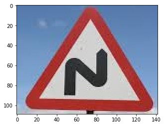

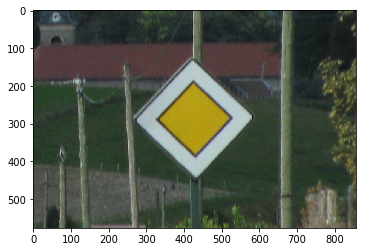

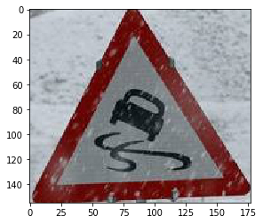

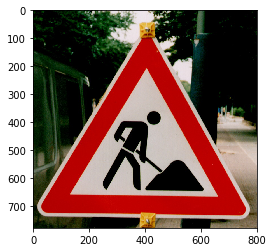

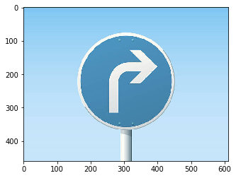

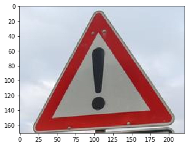

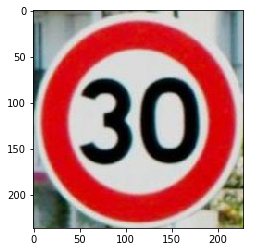

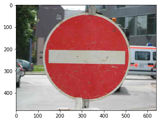

```python
### Load the images and plot them here.
### Feel free to use as many code cells as needed.
# JUMP
import cv2
import glob
import pathlib
import matplotlib.image as mpimg
import matplotlib.pyplot as plt
import os
import numpy as np


FILE_PATH = '/home/workspace/CarND-Traffic-Sign-Classifier-Project/test_images/*'
images = glob.glob(FILE_PATH)

#    print(images)
# print(f'Testing {images}')

x_internet_o, x_internet_i, y_internal_l, y_internet_n  = [], [], [], []

for index, fname in enumerate(images):
    base_name = os.path.basename(fname)
    base_name, _ = base_name.rsplit('.')
    internet_name, _, internet_label = base_name.rpartition('-')
    # Don't use open cv RGB is flipped
    #image = cv2.imread(fname)
    image = mpimg.imread(fname)
    plt.imshow(image, cmap='gray')
    plt.show()
    normailized_image = (image - 128) / 128

    resize_image = cv2.resize(normailized_image, (32, 32))   #resize image to 32x32

    x_internet_o.append(image)
    x_internet_i.append(resize_image)
    y_internal_l.append(int(internet_label))
    y_internet_n.append(internet_name)

xx_oo = np.array(x_internet_o)
xx_ii = np.array(x_internet_i, dtype = np.float32())
yy_ll = np.array(y_internal_l, dtype = np.uint8())
yy_nn = np.array(y_internet_n, dtype = np.str_)
#xx_ii = np.array(x_internet_i)
#yy_ll = np.array(y_internal_l)
#yy_nn = np.array(y_internet_n)
```

### Predict the Sign Type for Each Image

```python
### Run the predictions here and use the model to output the prediction for each image.
### Make sure to pre-process the images with the same pre-processing pipeline used earlier.
### Feel free to use as many code cells as needed.
```

```python
with tf.Session() as sess:
    saver.restore(sess, tf.train.latest_checkpoint('.'))

    logits_results = sess.run(tf.nn.softmax(logits, 1), feed_dict={x: xx_ii, keep_prob: 1.0})

logits_results
#print(f'Length logit_results: {len(logit_results)} - Images: {len(xx_ii)} - Labels: {len(yy_nn)}')
```

```
INFO:tensorflow:Restoring parameters from ./gs-traffic-model
```

[output not shown]

[output cut: 65 more lines]

[output not shown]

### Analyze Performance: Output Top 5 Softmax Probabilities For Each Image Found on the Web

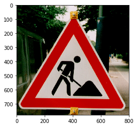

```
Index: 0 - Label: 25 - Name: road-work
Label :25 - confidence: 99.936646% - Match = True
Label :11 - confidence: 0.062079% - Match = False
Label :31 - confidence: 0.000635% - Match = False
Label :23 - confidence: 0.000343% - Match = False
Label :21 - confidence: 0.000126% - Match = False
```

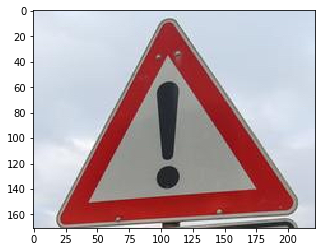

```
Index: 1 - Label: 18 - Name: general-caution
Label :18 - confidence: 99.991477% - Match = True
Label :26 - confidence: 0.008504% - Match = False
Label :11 - confidence: 1.9e-05% - Match = False
Label :27 - confidence: 1e-06% - Match = False
Label :1 - confidence: 0.0% - Match = False
```

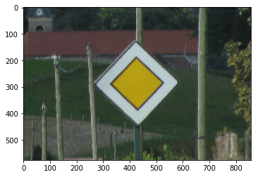

```
Index: 2 - Label: 12 - Name: priority-road
Label :12 - confidence: 92.076731% - Match = True
Label :9 - confidence: 1.98896% - Match = False
Label :17 - confidence: 1.047563% - Match = False
Label :38 - confidence: 0.727319% - Match = False
Label :25 - confidence: 0.585289% - Match = False
```

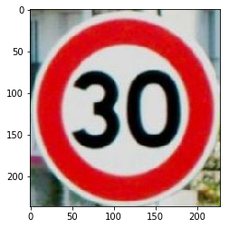

```
Index: 3 - Label: 1 - Name: 30km
Label :1 - confidence: 98.697972% - Match = True
Label :2 - confidence: 0.458498% - Match = False
Label :5 - confidence: 0.261219% - Match = False
Label :0 - confidence: 0.252363% - Match = False
Label :4 - confidence: 0.175161% - Match = False
```

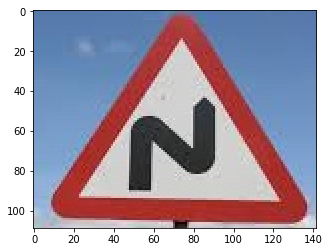

```
Index: 4 - Label: 21 - Name: double-curve
Label :20 - confidence: 52.93206% - Match = False
Label :18 - confidence: 36.532298% - Match = False
Label :11 - confidence: 4.1291% - Match = False
Label :26 - confidence: 1.978525% - Match = False
Label :25 - confidence: 0.841984% - Match = False
```

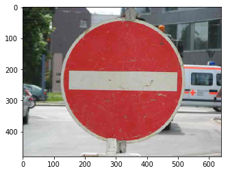

```
Index: 5 - Label: 17 - Name: no-entry
Label :17 - confidence: 100.0% - Match = True
Label :14 - confidence: 0.0% - Match = False
Label :12 - confidence: 0.0% - Match = False
Label :9 - confidence: 0.0% - Match = False
Label :3 - confidence: 0.0% - Match = False
```

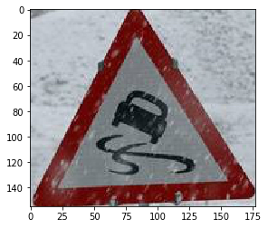

```
Index: 6 - Label: 23 - Name: slippery-road-sign
Label :22 - confidence: 99.99007% - Match = False
Label :28 - confidence: 0.004325% - Match = False
Label :20 - confidence: 0.003862% - Match = False
Label :29 - confidence: 0.000964% - Match = False
Label :25 - confidence: 0.000315% - Match = False
```

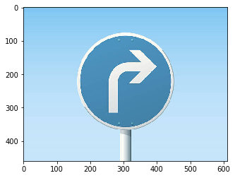

```
Index: 7 - Label: 33 - Name: turn-right-ahead
Label :33 - confidence: 98.704684% - Match = True
Label :35 - confidence: 1.062411% - Match = False
Label :9 - confidence: 0.044166% - Match = False
Label :5 - confidence: 0.034779% - Match = False
Label :3 - confidence: 0.028865% - Match = False
```

```python
with tf.Session() as sess:
    values, indices = sess.run(tf.nn.top_k(logits_results, k=5))
    for idx in range(len(xx_ii)):
        #print(f'Index: {idx} - len: {len(xx_ii)} - len: {len(yy_ll)} - len: {len(yy_nn)}')
        t_image, t_label, t_name = xx_oo[idx], yy_ll[idx], yy_nn[idx]
        #plt.imshow(t_image)
        plt.imshow(t_image, cmap='gray')
        plt.show()
        print(f'Index: {idx} - Label: {t_label} - Name: {t_name}')
        for i in range(5):
            match = False
            if yy_ll[idx] == indices[idx][i]:
                match = True

            conf = round((values[idx][i])*100,6)
            print(f'Label :{indices[idx][i]} - confidence: {conf}% - Match = {match}')
```

### Analyze Performance: Calculate the accuracy for new images

Model correctly predicted 6 out of 8 new images, with an accuracy of 75% on a very small sample set.

### Utility functions to pre-process images

```python
%%time
### Preprocess the data here. It is required to normalize the data. Other preprocessing steps could include
### converting to grayscale, etc.
### Feel free to use as many code cells as needed.
from sklearn.utils import shuffle
import tensorflow as tf
import numpy as np


import matplotlib.pyplot as plt
import matplotlib.gridspec as gridspec

def augment_data_grey(images):

    plt.figure(figsize = (10,10))
    gs1 = gridspec.GridSpec(11,6)
    gs1.update(wspace=0.01, hspace=0.21) # set the spacing between axes.

    count = 0
    print(f'Count: {count}')
    for i in range(6):
        ax1 = plt.subplot(gs1[i + count * 6])
        plt.axis('on')
        ax1.set_xticklabels([])
        ax1.set_yticklabels([])
        ax1.set_aspect('equal')

        plt.imshow(images[i])
        plt.text(2, 4, str(i), color='k', backgroundcolor='c')
        plt.axis('off')

    tf.image.rgb_to_hsv(
    images,
    name=None)

    convert_images = tf.image.rgb_to_grayscale(images, name=None)

    count += 1
    print(f'Count: {count} - Grey Batch')
    with tf.Session() as sess:
        sess.run(tf.global_variables_initializer())
        g_images = sess.run(convert_images)

    for i in range(6):
        # i = i + 1 # grid spec indexes from 0
        ax1 = plt.subplot(gs1[i + count * 6])
        plt.axis('on')
        ax1.set_xticklabels([])
        ax1.set_yticklabels([])
        ax1.set_aspect('equal')
        image = g_images[i]
        color_binary = np.dstack(( image, image, image)) * 255
        plt.imshow(color_binary)
        plt.text(2, 4, str(i), color='k', backgroundcolor='c')
        plt.axis('off')

    count += 1
    print(f'Count: {count} - Grey Channel')
    for i in range(6):
        # i = i + 1 # grid spec indexes from 0
        ax1 = plt.subplot(gs1[i + count * 6])
        plt.axis('on')
        ax1.set_xticklabels([])
        ax1.set_yticklabels([])
        ax1.set_aspect('equal')
        image = g_images[i]
        image = image[:,:,0]
        plt.imshow(image, cmap='gray')

        color_binary = np.dstack(( image, image, image)) * 255
        plt.imshow(color_binary)
        plt.text(2, 4, str(i), color='k', backgroundcolor='c')
        plt.axis('off')

    count += 1
    print(f'Count: {count} - Normalized')
    for i in range(6):
        # i = i + 1 # grid spec indexes from 0
        ax1 = plt.subplot(gs1[i + count * 6])
        plt.axis('on')
        ax1.set_xticklabels([])
        ax1.set_yticklabels([])
        ax1.set_aspect('equal')
        image = images[i]
        image = (image - 128) / 128

        #image = image[:,:,0]
        #print(image)
        #print(image.shape)

        plt.imshow(image)
        plt.text(2, 4, str(i), color='k', backgroundcolor='c')
        plt.axis('off')

    count += 1
    print(f'Count: {count} - Brightness Negative')
    for i in range(6):
        # i = i + 1 # grid spec indexes from 0
        ax1 = plt.subplot(gs1[i + count * 6])
        plt.axis('on')
        ax1.set_xticklabels([])
        ax1.set_yticklabels([])
        ax1.set_aspect('equal')
        image = images[i]
        #image_standardization = tf.image.per_image_standardization(image)

        #with tf.Session() as sess:
        #    sess.run(tf.global_variables_initializer())
        #    output_image = sess.run(image_standardization)


        change_op = tf.image.adjust_brightness(image, -0.3)

        with tf.Session() as sess:
            sess.run(tf.global_variables_initializer())
            output_image = sess.run(change_op)

        plt.imshow(output_image)
        plt.text(2, 4, str(i), color='k', backgroundcolor='c')
        plt.axis('off')

    max_delta = 0.5
    count += 1
    print(f'Count: {count} - Brightness Positive')
    for i in range(6):
        # i = i + 1 # grid spec indexes from 0
        ax1 = plt.subplot(gs1[i + count * 6])
        plt.axis('on')
        ax1.set_xticklabels([])
        ax1.set_yticklabels([])
        ax1.set_aspect('equal')
        image = images[i]

        change_op = tf.image.adjust_brightness(image, 0.3)

        with tf.Session() as sess:
            sess.run(tf.global_variables_initializer())
            output_image = sess.run(change_op)

        plt.imshow(output_image)
        plt.text(2, 4, str(i), color='k', backgroundcolor='c')
        plt.axis('off')

    count += 1
    print(f'Count: {count} - Contrast Negative')
    for i in range(6):
        # i = i + 1 # grid spec indexes from 0
        ax1 = plt.subplot(gs1[i + count * 6])
        plt.axis('on')
        ax1.set_xticklabels([])
        ax1.set_yticklabels([])
        ax1.set_aspect('equal')
        image = images[i]
        #image_standardization = tf.image.per_image_standardization(image)

        #with tf.Session() as sess:
        #    sess.run(tf.global_variables_initializer())
        #    output_image = sess.run(image_standardization)


        #change_saturation = tf.image.random_saturation(image, lower_range, upper_range, seed=None)
        # change_brightness = tf.image.adjust_brightness(image, max_delta)
        change_op = tf.image.adjust_contrast(image, 0.1)

        with tf.Session() as sess:
            sess.run(tf.global_variables_initializer())
            output_image = sess.run(change_op)

        plt.imshow(output_image)
        plt.text(2, 4, str(i), color='k', backgroundcolor='c')
        plt.axis('off')

    max_delta = 0.5
    count += 1
    print(f'Count: {count} - Contrast Positive')
    for i in range(6):
        # i = i + 1 # grid spec indexes from 0
        ax1 = plt.subplot(gs1[i + count * 6])
        plt.axis('on')
        ax1.set_xticklabels([])
        ax1.set_yticklabels([])
        ax1.set_aspect('equal')
        image = images[i]

        # change_brightness = tf.image.random_brightness(image, max_delta, seed=None)

        # change_brightness = tf.image.adjust_brightness(image, max_delta)
        # change_contrast = tf.image.random_contrast(image, lower_range, upper_range, seed=None)
        change_op = tf.image.adjust_contrast(image, 0.3)
```

```python
        with tf.Session() as sess:
            sess.run(tf.global_variables_initializer())
            output_image = sess.run(change_op)

        plt.imshow(output_image)
        plt.text(2, 4, str(i), color='k', backgroundcolor='c')
        plt.axis('off')

    lower_range = 0.01
    upper_range = 0.9
    count += 1
    print(f'Count: {count} - HUE Positive')
    for i in range(6):
        # i = i + 1 # grid spec indexes from 0
        ax1 = plt.subplot(gs1[i + count * 6])
        plt.axis('on')
        ax1.set_xticklabels([])
        ax1.set_yticklabels([])
        ax1.set_aspect('equal')
        image = images[i]

        change_contrast = tf.image.random_contrast(image, lower_range, upper_range, seed=None)
        change_hue = tf.image.adjust_hue(image, 0.3)

        with tf.Session() as sess:
            sess.run(tf.global_variables_initializer())
            output_image = sess.run(change_hue)

        plt.imshow(output_image)
        plt.text(2, 4, str(i), color='k', backgroundcolor='c')
        plt.axis('off')

    count += 1
    print(f'Count: {count} - HUE Negative')
    for i in range(6):
        # i = i + 1 # grid spec indexes from 0
        ax1 = plt.subplot(gs1[i + count * 6])
        plt.axis('on')
        ax1.set_xticklabels([])
        ax1.set_yticklabels([])
        ax1.set_aspect('equal')
        image = images[i]

        change_hue = tf.image.adjust_hue(image, -0.3)

        with tf.Session() as sess:
            sess.run(tf.global_variables_initializer())
            output_image = sess.run(change_hue)

        plt.imshow(output_image)
        plt.text(2, 4, str(i), color='k', backgroundcolor='c')
        plt.axis('off')

    hsv_transform = tf.image.rgb_to_hsv(images, name=None)

    count += 1
    print(f'Count: {count} - HSV')
    with tf.Session() as sess:
        sess.run(tf.global_variables_initializer())
        hsv_images = sess.run(hsv_transform)

    for i in range(6):
        # i = i + 1 # grid spec indexes from 0
        ax1 = plt.subplot(gs1[i + count * 6])
        plt.axis('on')
        ax1.set_xticklabels([])
        ax1.set_yticklabels([])
        ax1.set_aspect('equal')
        image = hsv_images[i]
        plt.imshow(image)
        plt.text(2, 4, str(i), color='k', backgroundcolor='c')
        plt.axis('off')

    plt.show()

def augment_batch_data(images, labels):

    print(f'Augment_batch_data Start')
    out_images = images.copy()
    out_labels = labels.copy()
    print(f'Augment_batch_data After Copy')
    for i in range(len(images)):
        image = images[i]
        label = labels[i]
        print(f'Augment_batch_data - index: {i} - label: {label}')

        normailized_image = (image - 128) / 128

        brightness_op = tf.image.adjust_brightness(image, 0.3)
        grayscale_op = tf.image.rgb_to_grayscale(image, name=None)

        with tf.Session() as sess:
            sess.run(tf.global_variables_initializer())
            brightness_image = sess.run(brightness_op)
            grayscale_image = sess.run(grayscale_op)
            # Add extra channels
            grayscale_channels = np.dstack(( grayscale_image, grayscale_image, grayscale_image)) * 255

        extra_images = np.array([normailized_image, brightness_image, grayscale_channels])
        extra_labels = np.array([label, label, label])
        # Append also works but you need to assign the result
        # print(f'First {np.append(out_labels, extra_labels)}')
        out_images = np.concatenate((out_images, extra_images))
        out_labels = np.concatenate((out_labels, extra_labels))

        if (i % 50 == 0):
            print(f'Augment_batch_data checkpoint - index: {i} - {label}')


    print(f'Augment_batch_data: Before len(labels), After: len(out_labels)')

    return shuffle(out_images, out_labels)

def save_pickle_date(X_train, y_train):
    print(f'Start Pickle - training data {len(X_train)} - shape {X_train.shape}')

    n_labels = np.empty_like(y_train)
    n_images, b_images, g_images = np.empty_like(X_train), np.empty_like(X_train), np.empty_like(X_train)
    nn_images, bb_images, gg_images = np.empty_like(X_train), np.empty_like(X_train), np.empty_like(X_train)
    a = np.ndarray(shape=(32,32, 3), dtype=X_train.dtype)

    print(f'Normalized: {len(n_images)}, Brigthness: {len(b_images)}, GREY: {len(g_images)}')
    print(f'Init: {n_images.shape}, Brigthness: {b_images.shape}, GREY: {g_images.shape}, Lable: {n_labels.shape}')


    for i in range(len(X_train)):
        image = X_train[i]
        label = y_train[i]
        print(f'ORG: image: {image.shape}, label: {label.shape} - {label}')

        normailized_image = (image - 128) / 128

        brightness_op = tf.image.adjust_brightness(image, 0.3)
        grayscale_op = tf.image.rgb_to_grayscale(image, name=None)

        with tf.Session() as sess:
            sess.run(tf.global_variables_initializer())
            brightness_image = sess.run(brightness_op)
            grayscale_image = sess.run(grayscale_op)
            # Add extra channels
            grayscale_channels = np.dstack(( grayscale_image, grayscale_image, grayscale_image)) * 255

            print(f'Normalized: {normailized_image.shape}, Brigthness: {brightness_image.shape}, GREY: {grayscale_image.shape}')

        # print(f'Index {i} value - Normalized: {normailized_image}, Brigthness: {brightness_image}, GREY: {grayscale_image}')

        n_images = np.append(n_images, normailized_image)
        b_images = np.append(b_images, brightness_image)
        g_images = np.append(g_images, grayscale_channels)
        # print(f'Index {i} value - Normalized: {n_images}, Brigthness: {b_images}, GREY: {g_images}')
        print(f'Index {i} ONE - Normalized: {len(n_images)}, Brigthness: {len(b_images)}, GREY: {len(g_images)}')

        print(f'Index {i} ONE - nn_images: {nn_images.shape}, normailized_image: {normailized_image.shape}')

        nn_images = np.concatenate((a, normailized_image))

        print(f'Index {i} TWO - Normalized: {len(nn_images)} - {len(a)} - {len(normailized_image)}')
```

```python
        if (i % 50 == 0):
            print(f'Augment_batch_data checkpoint - index: {i} - {label}')

    print(f'Augment_batch_data: Normalized: {len(n_images)}, Brigthness: {len(b_images)}, GREY: {len(g_images)}')

    data = {
        "features": n_images,
        "labels": n_labels
    }
    file_name = '/home/workspace/data/test_grey.p'
    file = open(file_name, 'wb')
    pickle.dump(data, file)

    data = {
        "features": b_images,
        "labels": n_labels
    }
    file_name = '/home/workspace/data/test_grey.p'
    file = open(file_name, 'wb')
    pickle.dump(data, file)

    data = {
        "features": g_images,
        "labels": n_labels
    }
    file_name = '/home/workspace/data/test_grey.p'
    file = open(file_name, 'wb')
    pickle.dump(data, file)


num_examples = 5
BATCH_SIZE = 5
EPOCHS = 1
print("augment_data...")
print()
for i in range(EPOCHS):
    X_train, y_train = shuffle(X_train, y_train)
    for offset in range(0, num_examples, BATCH_SIZE):
        end = offset + BATCH_SIZE
        batch_x, batch_y = X_train[offset:end], y_train[offset:end]
        #augment_data_grey(batch_x)
        # new_x, new_y = augment_batch_data(batch_x, batch_y)
        # print(f'Type: {type(new_y)} - length - {len(new_y)}')
        #augment_data_3(batch_x)
        save_pickle_date(batch_x, batch_y)
```

```python
%%time
from sklearn.utils import shuffle
import tensorflow as tf
import numpy as np

def save_pickle_date(X_train, y_train):
    print(f'Start Pickle - training data {len(X_train)} - shape {X_train.shape}')

    ll, nn, bb, gg  = [], [], [], []

    print(f'Labels: {len(ll)}, Normalized: {len(nn)}, Brigthness: {len(bb)}, GREY: {len(gg)}')

    for i in range(len(X_train)):
        image = X_train[i]
        label = y_train[i]

        normailized_image = (image - 128) / 128

        brightness_op = tf.image.adjust_brightness(image, 0.3)
        grayscale_op = tf.image.rgb_to_grayscale(image, name=None)

        with tf.Session() as sess:
            sess.run(tf.global_variables_initializer())
            #brightness_image = sess.run(brightness_op)
            grayscale_image = sess.run(grayscale_op)
            # Add extra channels
            grayscale_channels = np.dstack(( grayscale_image, grayscale_image, grayscale_image)) * 255

            # print(f'Normalized: {normailized_image.shape}, Brigthness: {brightness_image.shape}, GREY: {grayscale_image.shape}')

        ll.append(label)
        nn.append(normailized_image)
        #bb.append(brightness_image)
        gg.append(grayscale_channels)

        # print(f'Index {i} - Labels: {len(ll)}, Normalized: {len(nn)}, Brigthness: {len(bb)}, GREY: {len(gg)}')

        if (i % 20 == 0):
            print(f'Checkpoint - index: {i} - {label}')

    new_labels = np.array(ll, dtype = np.uint8())
    gray_images = np.array(gg, dtype = np.uint8())
    #brightness_images = np.array(bb, dtype = np.uint8())
    normailized_images = np.array(nn, dtype = np.float32())

    print(f'{gray_images.shape} - Length - {len(gray_images)}')
    # print(f'{brightness_images.shape} - Length - {len(brightness_images)}')
    print(f'{normailized_images.shape} - Length - {len(normailized_images)}')

    data = {
        "features": gray_images,
        "labels": new_labels
    }
    file_name = '/home/workspace/data/test_grey.p'
    file = open(file_name, 'wb')
    pickle.dump(data, file)

    #data = {
    #    "features": brightness_images,
    #    "labels": new_labels
    #}
    #file_name = '/home/workspace/data/test_brightness.p'
    #file = open(file_name, 'wb')
    #pickle.dump(data, file)

    data = {
        "features": normailized_images,
        "labels": new_labels
    }
    file_name = '/home/workspace/data/test_normalized.p'
    file = open(file_name, 'wb')
    pickle.dump(data, file)

def save_pickle_date_batch(X_train, y_train):
    print(f'Start Pickle - training data {len(X_train)} - shape {X_train.shape}')

    ll, nn, bb, gg  = [], [], [], []

    print(f'Labels: {len(ll)}, Normalized: {len(nn)}, Brigthness: {len(bb)}, GREY: {len(gg)}')

    convert_images = tf.image.rgb_to_grayscale(X_train, name=None)

    with tf.Session() as sess:
        sess.run(tf.global_variables_initializer())
        g_images = sess.run(convert_images)

    for i in range(len(g_images)):
        image = X_train[i]
        label = y_train[i]

        normailized_image = (image - 128) / 128

        # Add extra channels
        image = g_images[i]
        grayscale_channels = np.dstack(( image, image, image)) * 255

            # print(f'Normalized: {normailized_image.shape}, Brigthness: {brightness_image.shape}, GREY: {grayscale_image.shape}')

        ll.append(label)
        nn.append(normailized_image)
        #bb.append(brightness_image)
        gg.append(grayscale_channels)

        # print(f'Index {i} - Labels: {len(ll)}, Normalized: {len(nn)}, Brigthness: {len(bb)}, GREY: {len(gg)}')

        if (i % 200 == 0):
            print(f'Checkpoint - index: {i} - {label}')

    new_labels = np.array(ll, dtype = np.uint8())
    gray_images = np.array(gg, dtype = np.uint8())
    #brightness_images = np.array(bb, dtype = np.uint8())
    normailized_images = np.array(nn, dtype = np.float32())

    print(f'{gray_images.shape} - Length - {len(gray_images)}')
    # print(f'{brightness_images.shape} - Length - {len(brightness_images)}')
    print(f'{normailized_images.shape} - Length - {len(normailized_images)}')

    data = {
        "features": gray_images,
        "labels": new_labels
    }
    file_name = '/home/workspace/data/train_grey.p'
    file = open(file_name, 'wb')
    pickle.dump(data, file)

    #data = {
    #    "features": brightness_images,
    #    "labels": new_labels
    #}
    #file_name = '/home/workspace/data/test_brightness.p'
    #file = open(file_name, 'wb')
    #pickle.dump(data, file)

    data = {
        "features": normailized_images,
        "labels": new_labels
    }
    file_name = '/home/workspace/data/train_normalized.p'
    file = open(file_name, 'wb')
    pickle.dump(data, file)


num_examples = len(X_train)
BATCH_SIZE = len(X_train)
# num_examples = 9000
# BATCH_SIZE = 9000
EPOCHS = 1
print("augment_data...")
print()

X_train, y_train = shuffle(X_train, y_train)
for offset in range(0, num_examples, BATCH_SIZE):
    end = offset + BATCH_SIZE
    batch_x, batch_y = X_train[offset:end], y_train[offset:end]
    #augment_data_grey(batch_x)
    # new_x, new_y = augment_batch_data(batch_x, batch_y)
    # print(f'Type: {type(new_y)} - length - {len(new_y)}')
    #augment_data_3(batch_x)
    save_pickle_date_batch(batch_x, batch_y)
```